# Fundamentos de Pesquisa em Ciência da Computação 2

L2P2 - Ademar Neto

## **Explorando e Inferindo dados das Sessões, Buscas e Navegações da Wikimedia**

Neste relatório, usa-se a exploração de dados da Wikimedia Foundation, apresentando conclusões de inferências estatísticas sobre o dataset disponibilizado por eles e seguindo instruções da tarefa original, respondendo as quatro perguntas elencadas na mesma.

Nas seções um e dois estão as bibliotecas utilizadas e o os dados utilizados na análise. Na seção 3 estão as respostas para as perguntas elencadas no relatório e na última seção estão as conclusões obtidas das análises sobre os dados.

## 1. Importando as bibliotecas utilizadas

```r
library(tidyverse)
library(here)
library(lubridate)
library(knitr)
library(ggplot2)
library(scales)

theme_set(theme_bw())
```

## 2. Carregando os dados para análise

```r
dados_originais = read_csv(here::here("data/search_data.csv"))
head(100000)
```

```
## [1] 1e+05
```

```r
glimpse(dados_originais)
```

```
## Observations: 136,234
## Variables: 9
## $ session_id              <chr> "0000cbcb67c19c45", "0001382e027b2ea4"...
## $ search_index            <dbl> 1, 1, 1, 1, 2, 3, 4, 5, 6, 1, 1, 2, 1,...
## $ session_length          <dbl> 0, 303, 435, 58, 58, 58, 58, 58, 58, 0...
## $ session_start_timestamp <dbl> 2.016030e+13, 2.016031e+13, 2.016031e+...
## $ session_start_date      <dttm> 2016-03-03 15:20:45, 2016-03-07 08:49...
## $ group                   <chr> "b", "b", "b", "a", "a", "a", "a", "a"...
## $ results                 <dbl> 20, 18, 20, 20, 20, 20, 20, 20, 20, 1,...
## $ num_clicks              <dbl> 0, 1, 1, 0, 0, 0, 0, 0, 0, 0, 0, 1, 0,...
## $ first_click             <dbl> NA, 1, 1, NA, NA, NA, NA, NA, NA, NA, ...
```

Para ajudar na análise, foi adicionada uma nova coluna nos dados, essa coluna refere-se a data realizada na pesquisa, excluindo a informação de horas. Para isso foi utilizada a variável ‘session_start_date’ do dataset original.

```r
dados <- mutate(dados_originais, date = date(session_start_date))
```

### 2.1 Tratamento dos dados

Para uma análise melhor, foram realizados alguns tratamento nos dados, retirando registros com comportamentos indesejados.

O primeiro registro retirado foi onde o local do primeiro click é maior que a quantidade de resultados da busca (‘first_click’ > ‘results’).

```r
indesejados = dados%>%
    filter(first_click > results)

indesejados
```

| session_id | search_index | session_length | session_start_timestamp | session_start_date | group | results | num_clicks | first_click | date |
| --- | --- | --- | --- | --- | --- | --- | --- | --- | --- |
| 012460df6605630a | 3 | 599 | 2.016031e+13 | 2016-03-07 17:20:49 | a | 20 | 1 | 21 | 2016-03-07 |
| 0705f6124671c837 | 6 | 602 | 2.016031e+13 | 2016-03-08 06:05:38 | a | 20 | 1 | 38 | 2016-03-08 |
| 07d1244fb0ecfa18 | 5 | 496 | 2.016030e+13 | 2016-03-04 20:32:29 | a | 20 | 1 | 94 | 2016-03-04 |
| 0c02236a143c5f2d | 2 | 783 | 2.016030e+13 | 2016-03-04 12:10:50 | a | 0 | 1 | 1 | 2016-03-04 |
| 0d050fd8343f9ab7 | 2 | 194 | 2.016031e+13 | 2016-03-05 11:48:03 | a | 12 | 1 | 32 | 2016-03-05 |
| 0d6eb81512d879e9 | 3 | 89 | 2.016030e+13 | 2016-03-02 13:39:10 | a | 20 | 2 | 34 | 2016-03-02 |
| 10541aaefd0e6edc | 3 | 245 | 2.016030e+13 | 2016-03-03 19:56:01 | a | 2 | 1 | 6 | 2016-03-03 |
| 114e3fa48cc98264 | 3 | 238 | 2.016030e+13 | 2016-03-02 19:18:56 | a | 8 | 1 | 37 | 2016-03-02 |
| 114e3fa48cc98264 | 11 | 238 | 2.016030e+13 | 2016-03-02 19:20:40 | a | 19 | 2 | 27 | 2016-03-02 |
| 12060c71917f4a7a | 1 | 25 | 2.016031e+13 | 2016-03-08 06:25:56 | b | 1 | 1 | 8 | 2016-03-08 |

[output cut: 310 more lines]

Outro registro indesejado é onde houveram clicks e não existe registro do primeiro click (‘num_clicks’ > 0 & is.na(‘first_click’).

```r
indesejados2 = dados%>%
    filter(num_clicks > 0 & is.na(first_click))

indesejados2
```

| session_id | search_index | session_length | session_start_timestamp | session_start_date | group | results | num_clicks | first_click | date |
| --- | --- | --- | --- | --- | --- | --- | --- | --- | --- |
| 1a9459a338122787 | 1 | 263 | 2.01603e+13 | 2016-03-02 01:11:49 | a | 20 | 1 | NA | 2016-03-02 |
| 5caa35c50d2f5306 | 2 | 55 | 2.01603e+13 | 2016-03-01 01:07:25 | a | 1 | 1 | NA | 2016-03-01 |
| ceac717235e5c8de | 2 | 759 | 2.01603e+13 | 2016-03-03 09:45:29 | a | 2 | 8 | NA | 2016-03-03 |

```r
dados%>%
  filter((first_click <= results) | ( num_clicks == 0 & is.na(first_click)))
```

| session_id | search_index | session_length | session_start_timestamp | session_start_date | group | results | num_clicks | first_click | date |
| --- | --- | --- | --- | --- | --- | --- | --- | --- | --- |
| 0000cbcb67c19c45 | 1 | 0 | 2.016030e+13 | 2016-03-03 15:20:45 | b | 20 | 0 | NA | 2016-03-03 |
| 0001382e027b2ea4 | 1 | 303 | 2.016031e+13 | 2016-03-07 08:49:55 | b | 18 | 1 | 1 | 2016-03-07 |
| 0001e8bb90445cb2 | 1 | 435 | 2.016031e+13 | 2016-03-05 09:24:15 | b | 20 | 1 | 1 | 2016-03-05 |
| 000216cf18ae1ab1 | 1 | 58 | 2.016031e+13 | 2016-03-08 16:19:46 | a | 20 | 0 | NA | 2016-03-08 |
| 000216cf18ae1ab1 | 2 | 58 | 2.016031e+13 | 2016-03-08 16:19:53 | a | 20 | 0 | NA | 2016-03-08 |
| 000216cf18ae1ab1 | 3 | 58 | 2.016031e+13 | 2016-03-08 16:20:32 | a | 20 | 0 | NA | 2016-03-08 |
| 000216cf18ae1ab1 | 4 | 58 | 2.016031e+13 | 2016-03-08 16:20:38 | a | 20 | 0 | NA | 2016-03-08 |
| 000216cf18ae1ab1 | 5 | 58 | 2.016031e+13 | 2016-03-08 16:20:43 | a | 20 | 0 | NA | 2016-03-08 |
| 000216cf18ae1ab1 | 6 | 58 | 2.016031e+13 | 2016-03-08 16:20:44 | a | 20 | 0 | NA | 2016-03-08 |
| 000527f711d50dfc | 1 | 0 | 2.016031e+13 | 2016-03-08 05:33:00 | b | 1 | 0 | NA | 2016-03-08 |

[output cut: 9990 more lines]

### 2.2 Variáveis Utilizadas nas análises

As variáveis utilizadas podem serem vistas abaixo:

`group` : Um marcador (“a” ou “b”);

`results` : Número de ocorrências retornadas para o usuário;

`num_clicks`: Número de ocorrências clicadas pelo usuário;

`first_click`: Posição da ocorrência que o usuário clicou primeiro;

`session_start_date`: Data do início da pesquisa;

`session_length`: Duração da sessão.

## 3. Respostas para as questões elencadas

### 3.1 Qual é a taxa de cliques geral diária? Como isso varia entre os grupos?

Analisou-se, em primeiro lugar, os quartis da variável `num_clicks`. Foi verificado que, em média, o grupo A tem maior número de clicks que o grupo B. No entanto, pode ser observado que o grupo A tem mais pesquisa no site que o grupo B, podendo haver um enviesamento dos dados.

```r
with(dados, tapply(num_clicks, group, summary))
```

```
## $a
##    Min. 1st Qu.  Median    Mean 3rd Qu.    Max.
##   0.000   0.000   0.000   0.361   1.000  36.000
##
## $b
##    Min. 1st Qu.  Median    Mean 3rd Qu.    Max.
##  0.0000  0.0000  0.0000  0.1535  0.0000  3.0000
```

Para melhorar a análise, na Figura 1 está a distribuição da quantidade de clicks separada por grupos. Assim, Podemos observar que existem mais ocorrências do grupo A.

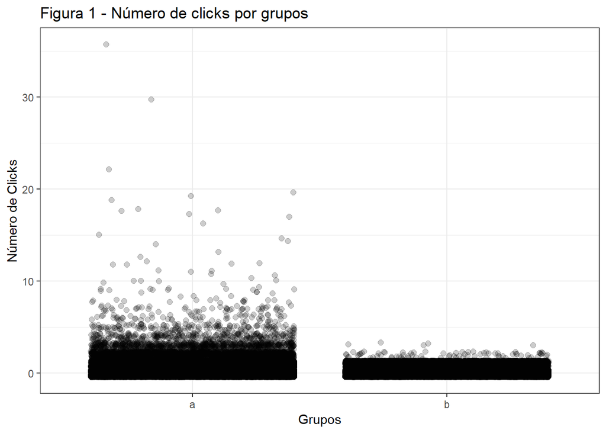

```r
dados %>%
    ggplot(aes(x = group, y = num_clicks)) +
     geom_jitter(alpha = .2, size = 2)  + labs(y= "Número de Clicks", x="Grupos", title="Figura 1 - Número de clicks por grupos")
```

Outra análise é avaliar o comportamento da variável `num_clicks` por dia para cada grupo.

```r
dados %>%
    group_by(round_date(date , unit="day"), group) %>%
    summarise(somatorio = sum(num_clicks)) %>%
    head()
```

| round_date(date, unit = "day") | group | somatorio |
| --- | --- | --- |
| 2016-03-01 | a | 5920 |
| 2016-03-01 | b | 723 |
| 2016-03-02 | a | 5919 |
| 2016-03-02 | b | 754 |
| 2016-03-03 | a | 5763 |
| 2016-03-03 | b | 791 |

Como pode ser visto na análise acima, o número de clicks do grupo A sempre foi superior o número de clicks do grupo B.

### 3.2 Quais resultados as pessoas tendem a tentar primeiro? Como isso muda no dia-a-dia?

A variável que armazena a posição do primeiro resultado de busca clicada por sessão é a `first_click`. Com isso, para essa variável são utilizados somentes valores diferentes de NA e maiores que zero (diferente de zero, já que são valores positivos).

```r
dados = dados %>%
    filter(!is.na(first_click)) %>%
    filter(first_click != 0)
glimpse(dados)
```

```
## Observations: 33,194
## Variables: 10
## $ session_id              <chr> "0001382e027b2ea4", "0001e8bb90445cb2"...
## $ search_index            <dbl> 1, 1, 2, 1, 1, 1, 2, 2, 1, 3, 2, 1, 1,...
## $ session_length          <dbl> 303, 435, 43, 339, 444, 112, 213, 443,...
## $ session_start_timestamp <dbl> 2.016031e+13, 2.016031e+13, 2.016031e+...
## $ session_start_date      <dttm> 2016-03-07 08:49:55, 2016-03-05 09:24...
## $ group                   <chr> "b", "b", "a", "a", "b", "a", "a", "a"...
## $ results                 <dbl> 18, 20, 1, 20, 20, 20, 20, 20, 9, 20, ...
## $ num_clicks              <dbl> 1, 1, 1, 3, 1, 1, 1, 1, 1, 1, 1, 1, 1,...
## $ first_click             <dbl> 1, 1, 1, 1, 5, 1, 1, 1, 1, 4, 1, 1, 2,...
## $ date                    <date> 2016-03-07, 2016-03-05, 2016-03-05, 2...
```

Feito isso, iremos analisar os quartis da variável `first_click`.

```r
with(dados, tapply(first_click, group, summary))
```

```
## $a
##     Min.  1st Qu.   Median     Mean  3rd Qu.     Max.
##    1.000    1.000    1.000    4.416    2.000 4103.000
##
## $b
##    Min. 1st Qu.  Median    Mean 3rd Qu.    Max.
##   1.000   1.000   1.000   1.976   2.000  35.000
```

Observando os resultados que no grupo B os usuários clicam em resultados mais iniciais (Mean 1.976) relacionado as pesquisas do grupo A (Mean 4.416).

Para obter mais elementos para e melhorar a análise, também iremos analisar a distribuição da variável (`first_click`).

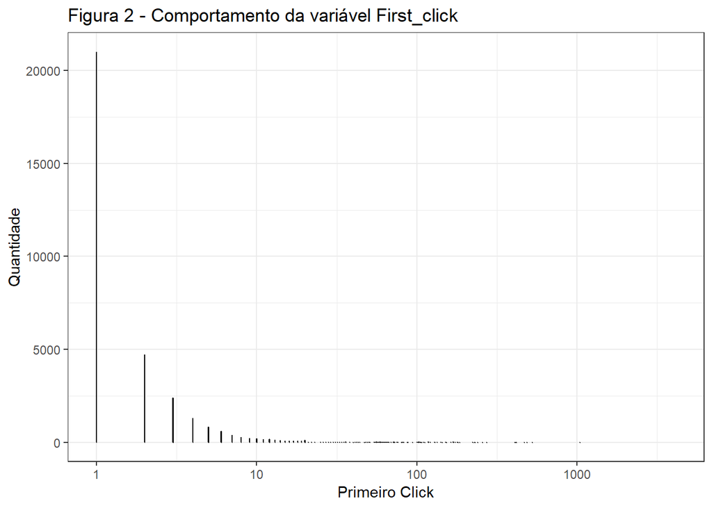

```r
dados %>%
    ggplot(aes(x=first_click)) +
    geom_bar(bins=10, fill = "white", color = "black") +
    scale_x_log10() +
    labs(y = "Quantidade", x = "Primeiro Click", title = "Figura 2 - Comportamento da variável First_click")
```

Apesar de ter alguns valores fora da faixa, é possível observar que a maioria dos clicks estão entre os 10 primeiros links.

Agora será mostrado a distribuição dos cliques por dia, pra saber se muda alguma coisa em relação aos clicks geral.

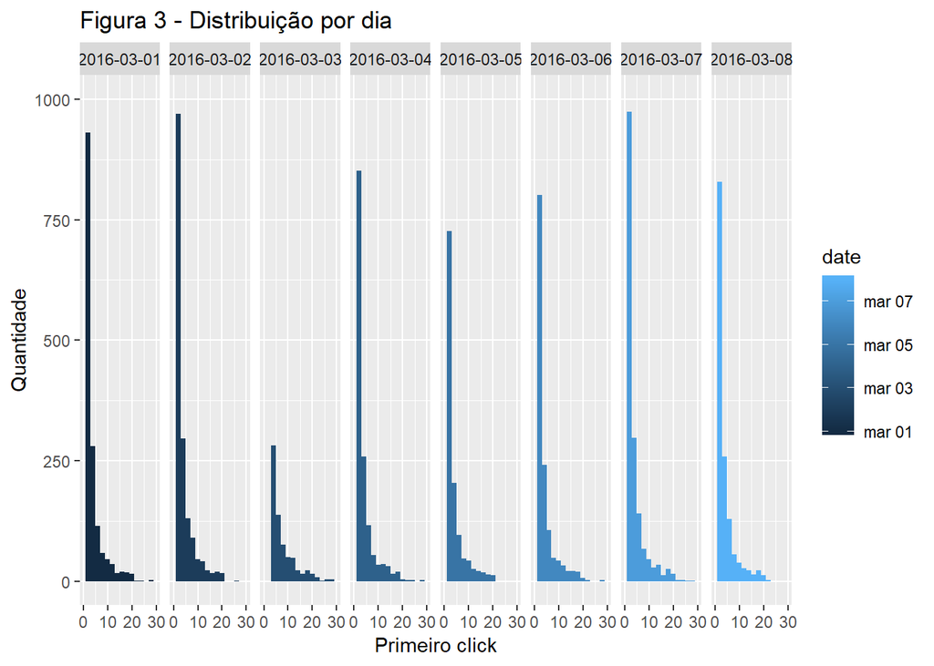

```r
dados %>%
    arrange(date)%>%
    ggplot(aes(x = first_click, fill = date)) +
    geom_histogram(binwidth = 2) +
    scale_x_continuous(limits=c(0, 30)) +
    scale_y_continuous(limits=c(0, 1000)) +
    facet_grid(~ date) +
    labs(title = "Figura 3 - Distribuição por dia", x = "Primeiro click", y = "Quantidade") + theme_gray()
```

Visualizando esse histograma, vimos que todos os dias, o usuário clica pela primeira vez, na maioria dos dias, também entre os 10 primeiros links.

### 3.3 Qual a taxa de resultados zero no geral? Como isso varia entre os grupos?

Para responder esse questionamento, deve ser considerado, para a variável `results`, valores iguais a `0`. Com isso, na Figura 4 exibe a distribuição de zeros nos resultados por data de ocorrência. Para isso foi criado o `sessao_por_data` dos dados originais.

```r
dados_originais <- dados_originais%>%
    filter(!is.na(results))

glimpse(dados)
```

```
## Observations: 33,194
## Variables: 10
## $ session_id              <chr> "0001382e027b2ea4", "0001e8bb90445cb2"...
## $ search_index            <dbl> 1, 1, 2, 1, 1, 1, 2, 2, 1, 3, 2, 1, 1,...
## $ session_length          <dbl> 303, 435, 43, 339, 444, 112, 213, 443,...
## $ session_start_timestamp <dbl> 2.016031e+13, 2.016031e+13, 2.016031e+...
## $ session_start_date      <dttm> 2016-03-07 08:49:55, 2016-03-05 09:24...
## $ group                   <chr> "b", "b", "a", "a", "b", "a", "a", "a"...
## $ results                 <dbl> 18, 20, 1, 20, 20, 20, 20, 20, 9, 20, ...
## $ num_clicks              <dbl> 1, 1, 1, 3, 1, 1, 1, 1, 1, 1, 1, 1, 1,...
## $ first_click             <dbl> 1, 1, 1, 1, 5, 1, 1, 1, 1, 4, 1, 1, 2,...
## $ date                    <date> 2016-03-07, 2016-03-05, 2016-03-05, 2...
```

```r
sessao_por_data = dados_originais %>%
    group_by(date(session_start_date)) %>%
    summarize(total_sessoes_por_data = n(),
              total_sessoes_com_zero_resultados_por_data = sum(results == 0),
              taxa = (total_sessoes_com_zero_resultados_por_data/total_sessoes_por_data) * 100)


glimpse(sessao_por_data)
```

```
## Observations: 8
## Variables: 4
## $ `date(session_start_date)`                 <date> 2016-03-01, 2016-0...
## $ total_sessoes_por_data                     <int> 18374, 18902, 19159...
## $ total_sessoes_com_zero_resultados_por_data <int> 3447, 3589, 3443, 3...
## $ taxa                                       <dbl> 18.76020, 18.98741,...
```

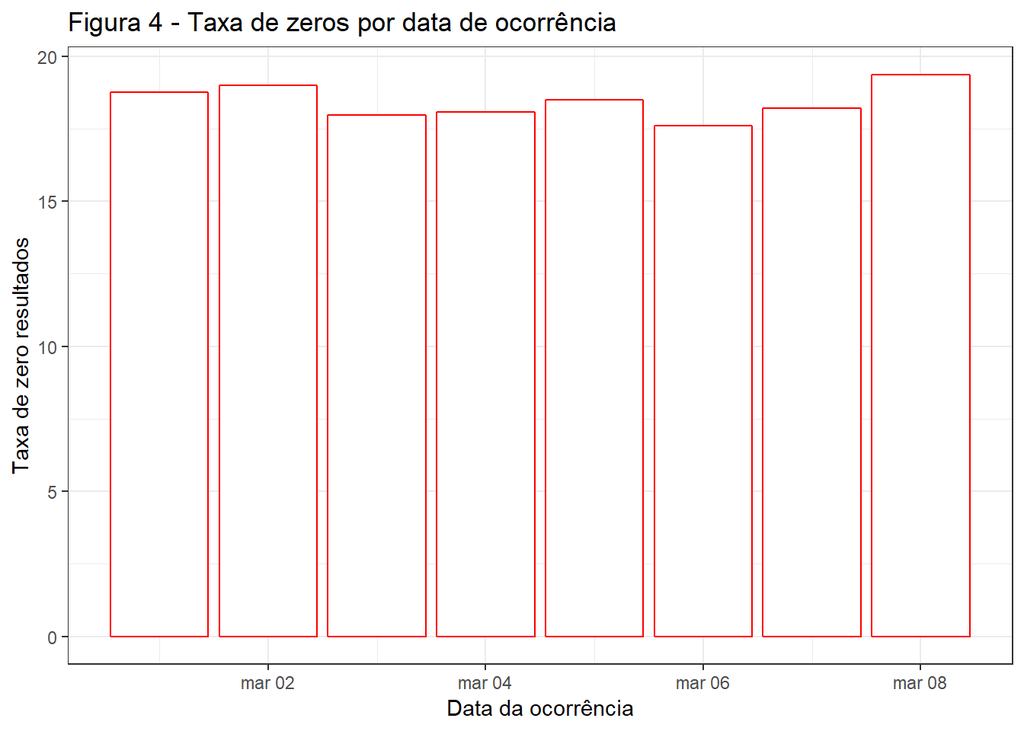

```r
sessao_por_data %>%
    ggplot(aes(y = taxa, x = `date(session_start_date)`)) +
    geom_bar(stat = "identity", fill = "white", color = "red") +
    labs(x = "Data da ocorrência", y = "Taxa de zero resultados", title = "Figura 4 - Taxa de zeros por data de ocorrência")
```

No geral, a taxa de ocorrências de zero resultados, que pode ser visualizada na Figura 4, se aproxima de 20% nas datas que contém nos dados. O valor, em média, das sessões diárias, onde os usuários obteram zero resultados são de 18,43%. Segue o cálculo abaixo.

```r
print(mean(sessao_por_data$taxa))
```

```
## [1] 18.43512
```

Para responder segunda parte da pergunta, como isso varia entre os grupos, foi criado a `sessao_por_grupo`. Depois, na Figura 5, foi plotado gráfico para analisar melhor os dados.

```r
sessao_por_grupo <- dados_originais %>%
    group_by(group, results) %>%
    summarise(total_sessao_por_grupo = n()) %>%
    mutate(sessao_por_grupo = total_sessao_por_grupo / sum(total_sessao_por_grupo) * 100)


glimpse(sessao_por_grupo)
```

```
## Observations: 117
## Variables: 4
## Groups: group [2]
## $ group                  <chr> "a", "a", "a", "a", "a", "a", "a", "a",...
## $ results                <dbl> 0, 1, 2, 3, 4, 5, 6, 7, 8, 9, 10, 11, 1...
## $ total_sessao_por_grupo <int> 16902, 4855, 3025, 2107, 1581, 1392, 11...
## $ sessao_por_grupo       <dbl> 18.360563135, 5.273963674, 3.286043278,...
```

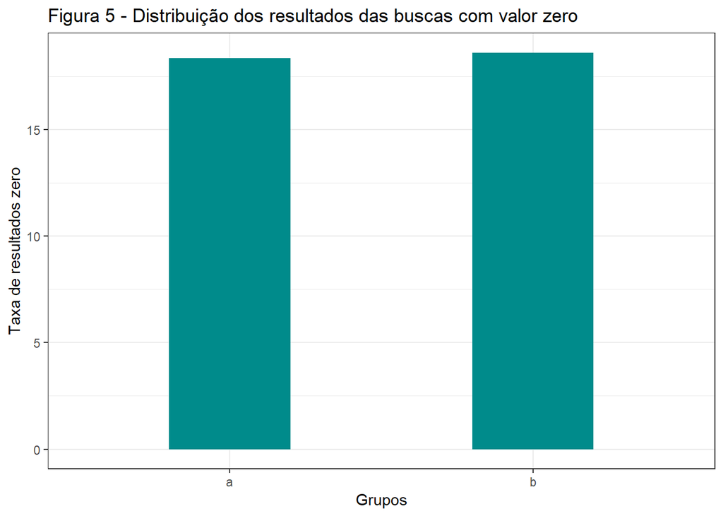

```r
sessao_por_grupo %>%
    filter(results==0) %>%
    ggplot(aes(x = group, y = sessao_por_grupo)) +
    geom_col(width = .4,  fill = "darkcyan") +
    labs(title="Figura 5 - Distribuição dos resultados das buscas com valor zero",
       x="Grupos",  y ="Taxa de resultados zero")
```

### 3.4 A duração da sessão é aproximadamente o tempo entre o primeiro e o último evento de uma sessão. Escolha uma variável do conjunto de dados e descreva sua relação com o tamanho da sessão. Visualize o relacionamento.

Foram relacionadas as variáveis duração da sessão e o índice do primeiro click, pra saber se quando o usuário clica nos primeiros links ele dura mais tempo ou não, na sessão.

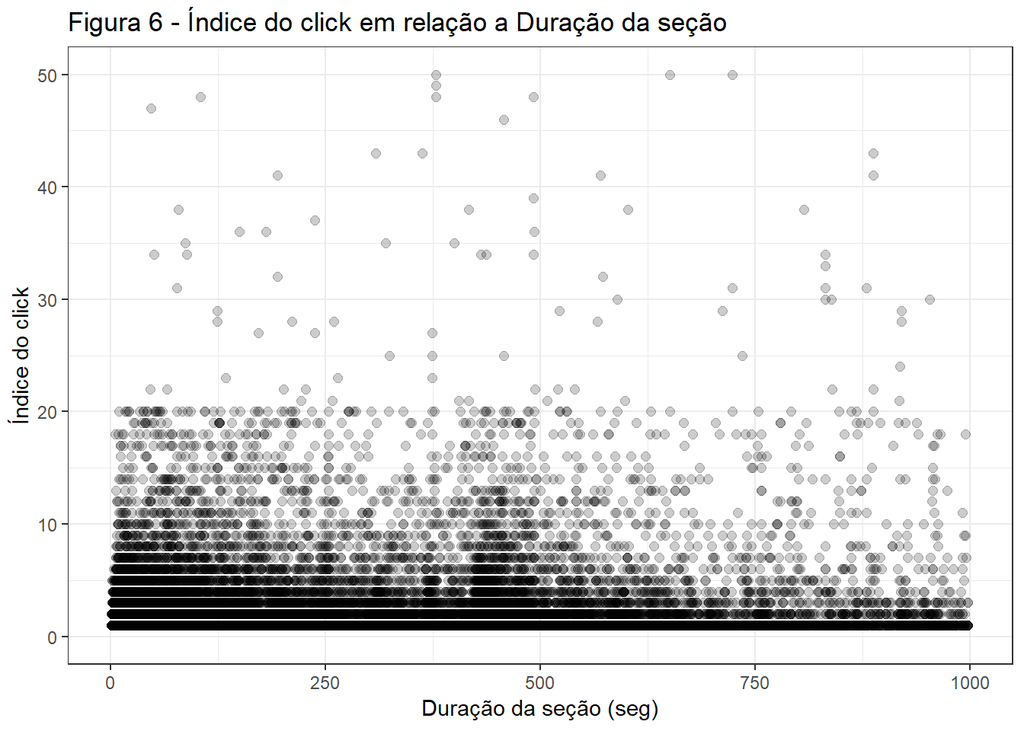

```r
dados %>%
    filter(first_click <= 50)  %>%
    ggplot(aes(y = first_click, x = session_length)) +
    geom_point(alpha = .2, size = 2) +
    ggtitle("Figura 6 - Índice do click em relação a Duração da seção") +
    scale_y_continuous(limits=c(0, 50)) +
    scale_x_continuous(limits=c(0,1000)) +
    labs(y = "Índice do click",x = "Duração da seção (seg)")
```

## 4. Conclusões

Sabe-se que a média geral de clicks é maior para o grupo A. Assim, como o número de ocorrências é maior para esse grupo (Figura 1), foi verificado também por dia o comportamento da variável `num_clicks`. Visto isso, concluímos que os clicks no grupo A realmente são maiores que o grupo B.

Em relação em qual link o usuário clica primeiro, verificamos (Figura 2 e Figura 3) que os mesmos clicam pela primeira vez, na maioria das vezes, entre os primeiros 10 links retornados. Contudo, temos uma taxa de 18% de retorno de buscas com resultado zero, no geral (Figura 4). Em relação aos grupos, praticamente, o A e o B têm a mesma quantidade de buscas que retornam zero links (Figura 5).

[output not shown]